# WM_tasks_Markdown

Christoph Voelter

November 24, 2018

## Summary

Chimpanzees (N=28) performed above chance in the the WM grid task (DV: distance between chosen cell location and the hiding location of the food) and the WM Boxes task (DV: count of mistakes on platform 1) but not in the updating task (DV: count of mistakes on platform 1 within the first 4 attempts; this is also the case for other DVs).  
Correlation coefficients between the updating task and the grid / boxes task are positive (and some are statistically significant, e.g. between the grid distance DV and updating Platform 1 performance) but larger sample sizes are needed before any conclusions can be drawn.

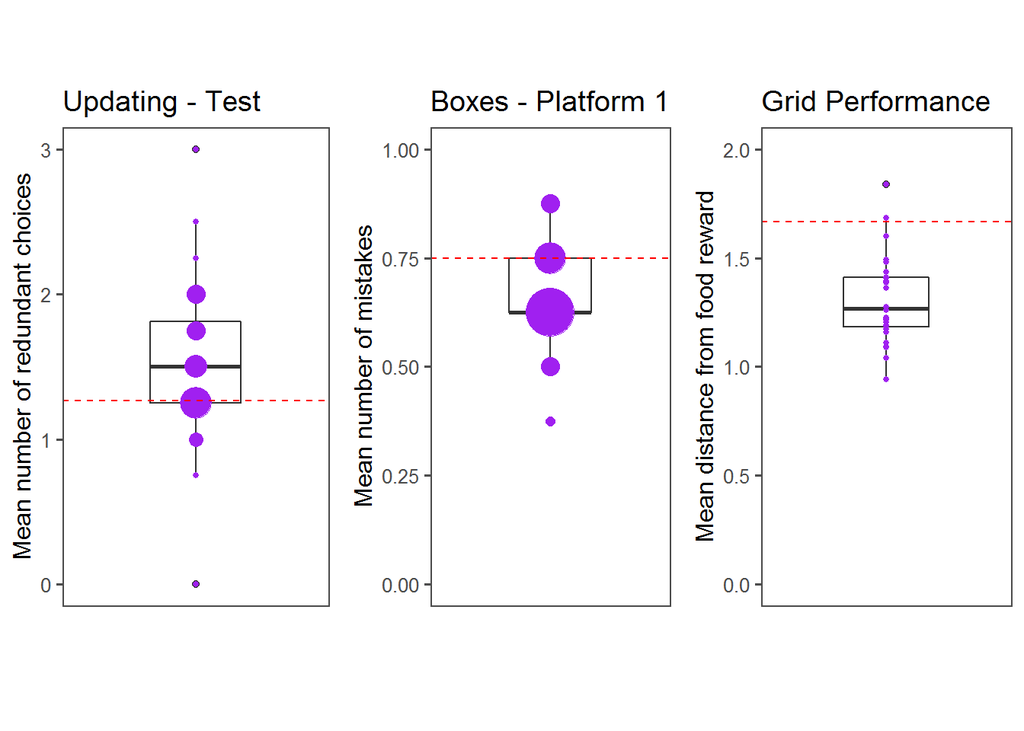

* Dashed line: chance level  
* Smaller values indicate better performance in all three tasks / DVs

## Test against chance

### Updating task

Comparison to simulation of random sampling (drawing without replacement) based on 100000 iterations. The mean number of unique and repeated choices is computed from these simulations and used as the hypothetical chance value.

#### Training performance

##### 4 Boxes training:

- Number of redundant searches with 4 boxes (up to 5 redundant searches) vs chance value (3.16): Mean = 2.92, 95% CI [2.38, 3.45], *t*(27)=-0.94, *p*=0.356
- Number of redundant searches with 4 boxes (first 4 choices) vs chance value (1.26): Mean = 1.32, 95% CI [1.12, 1.51], *t*(27)=0.59, *p*=0.56

##### 5 Boxes training:

- Number of redundant searches with 5 boxes (up to 5 mistakes) vs chance value (3.88): Mean = 3.46, 95% CI [2.94, 3.97], *t*(27)=-1.68, *p*=0.104
- Number of redundant searches with 5 boxes (first 5 choices) vs chance value (1.63): Mean = 1.69, 95% CI [1.44, 1.94], *t*(27)=0.5, *p*=0.624

#### Test performance

- Number of redundant searches with test trials (platform 1 and 2; up to 6 redundant searches) vs chance value (4.75): Mean = 4.96, 95% CI [4.61, 5.32], *t*(27)=1.23, *p*=0.231
- Number of redundant searches with test trials (platform 1: first 4 choices) vs chance value (1.265): Mean = 1.53, 95% CI [1.3, 1.75], *t*(27)=2.39, *p*=0.024

### WM Boxes

#### Platform 1 performance

- Mean number of mistakes on platform 1 vs chance value (0.75): Mean = 0.66, 95% CI [0.6, 0.71], *t*(27)=-3.58, *p*=0.001

### WM Grid

#### Distance between chosen cell and baited cell on the grid

Distance calculation: $\sqrt{(Chosen_X-Food_X)^2+(Chosen_Y-Food_Y)^2}$

##### Test against random choices of all 16 grid cells.

The simulation is based on 1000000 iterations of 12 random choices of a cell on the 4x4 grid. The distance between these random choices and the hiding location of the food reward was then calculated. The mean distance from the food reward of the these random choices is used as the hypothetical chance value.

- Mean distance between chosen cell and baited cell vs chance value (all cells: 1.954): Mean = 1.31, 95% CI [1.23, 1.39], *t*(27)=-16.94, *p*=0

##### Test against inner cell preference

The simulation is identical to the aforementioned one but only the inner cells are sampled from resulting in a smaller average distance from the food reward.

- Mean distance between chosen cell and baited cell vs chance value (inner cells only: 1.667): Mean = 1.31, 95% CI [1.23, 1.39], *t*(27)=-9.39, *p*=0

## Plotting correlations

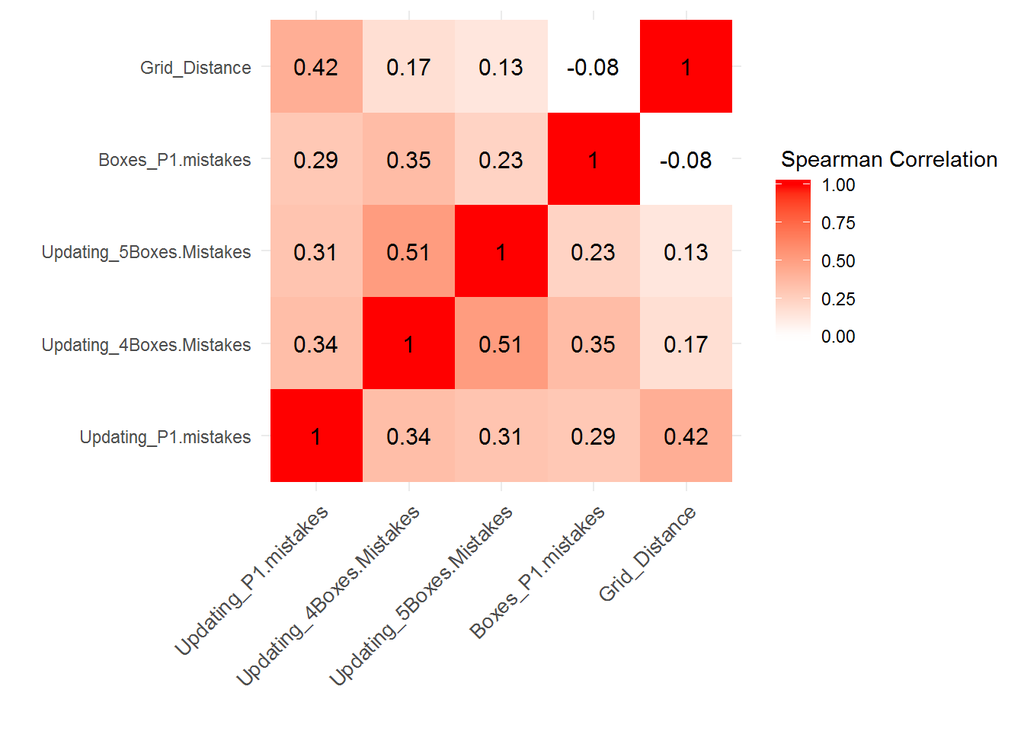